# lab4-Chen

Weixuan Chen

2/22/2023

```r
library(ggplot2)
```

```r
 # Download the data
d1 <- read.csv("http://faraway.neu.edu/biostats/lab4_dataset1.csv")
d1
```

```
##      treatment age      score
## 1      control  15  4.3567227
## 2      control  23  3.8493535
## 3      control  23  6.9803791
## 4      control  19  1.0894147
## 5      control  11 23.9647335
## 6      control  20  1.3979789
## 7      control  21  4.6481514
## 8      control  20  2.4207560
## 9      control  16  3.4874855
## 10     control  24 59.5708610
## 11     control  19  7.5187178
## 12     control  15  2.0415299
## 13     control  16  1.4324617
## 14     control  16 11.5905151
```

[output cut: 106 more lines]

## Task 1

## 1

H0:${\mu_{control}=\mu_{treatment} }$ H1:Not H0(mean of two groups differs)

## 2

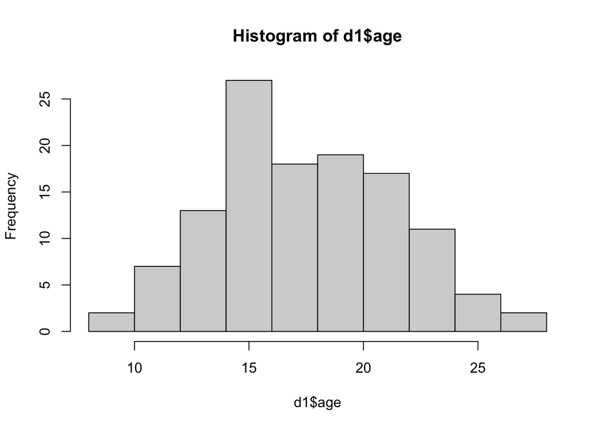

```r
hist(d1$age)
```

## 3

It may deviate from normal distribution a little.

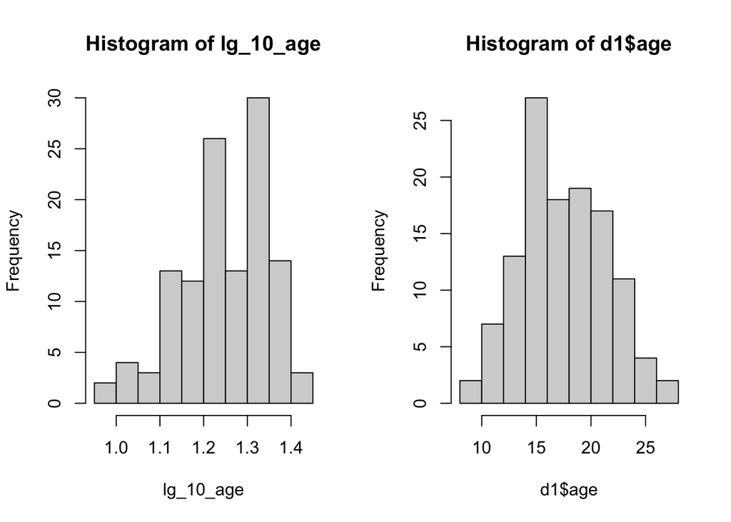

```r
lg_10_age <- log10(d1$age)
par(mfrow=c(1,2))
hist(lg_10_age)
hist(d1$age)
```

The transformation does not seem to be necessary

## 4

```r
d1_ctl <- subset(d1, treatment == "control")
d1_vac <- subset(d1, treatment == "vaccinated")
t.test(d1_ctl$age, d1_vac$age, paired = TRUE)
```

```
##
##  Paired t-test
##
## data:  d1_ctl$age and d1_vac$age
## t = -0.11614, df = 59, p-value = 0.9079
## alternative hypothesis: true mean difference is not equal to 0
## 95 percent confidence interval:
##  -1.519114  1.352448
## sample estimates:
## mean difference
##     -0.08333333
```

We have p-value = 0.91, which we have to not reject the null hypothesis. So we don’t have enough evidence to show that the mean of two groups are different.

## 5

```r
ctl_mean <- mean(d1_ctl$age)
ctl_sd <- sd(d1_ctl$age)
dim(d1_ctl)
```

```
## [1] 60  3
```

```r
ctl_upper <- ctl_mean + ctl_sd/sqrt(60)
ctl_lower <- ctl_mean - ctl_sd/sqrt(60)
print(paste0("The upper bound is ", ctl_upper))
```

```
## [1] "The upper bound is 18.4976111755968"
```

```r
print(paste0("The lower bound is ", ctl_lower))
```

```
## [1] "The lower bound is 17.4357221577365"
```

```r
vac_mean <- mean(d1_vac$age)
vac_sd <- sd(d1_vac$age)
dim(d1_vac)
```

```
## [1] 60  3
```

```r
vac_upper <- vac_mean + vac_sd/sqrt(60)
vac_lower <- vac_mean - vac_sd/sqrt(60)
print(paste0("The upper bound is ", vac_upper))
```

```
## [1] "The upper bound is 18.5396816676099"
```

```r
print(paste0("The lower bound is ", vac_lower))
```

```
## [1] "The lower bound is 17.5603183323901"
```

## 6

H0: mean score of control group has no difference than treatment group H1: Not H0 (has difference between two groups)

## 7

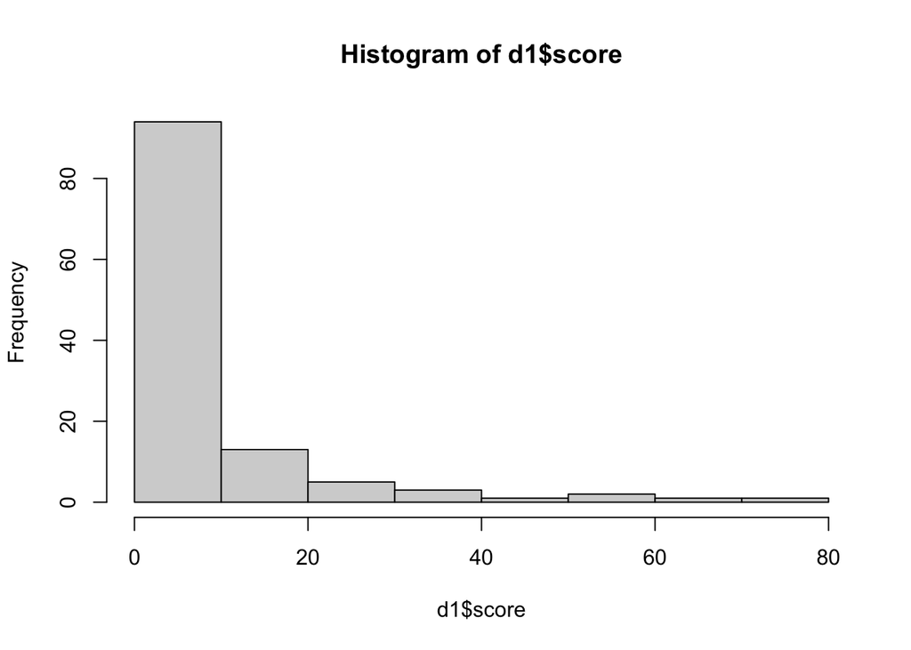

```r
hist(d1$score)
```

Definitely not normal

## 8

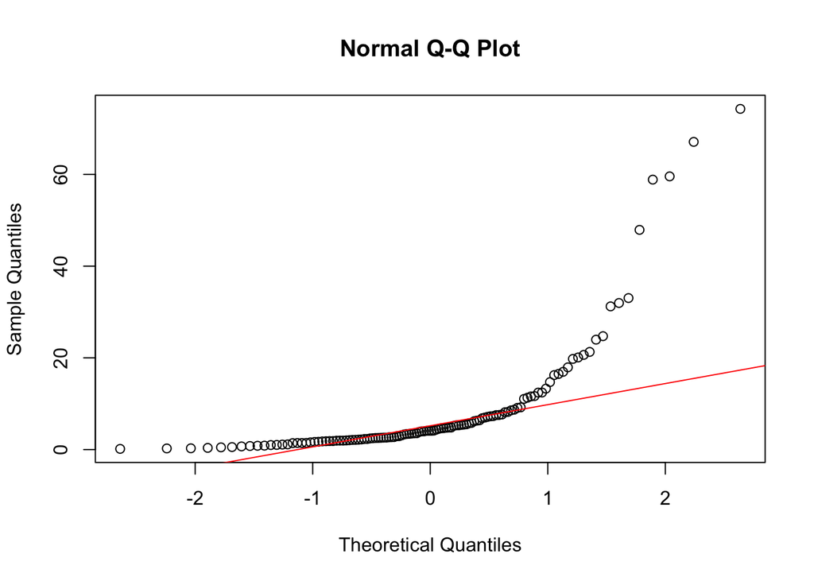

```r
qqnorm(d1$score)
qqline(d1$score, col="red")
```

Apparently, these two lines are not similar

## 9

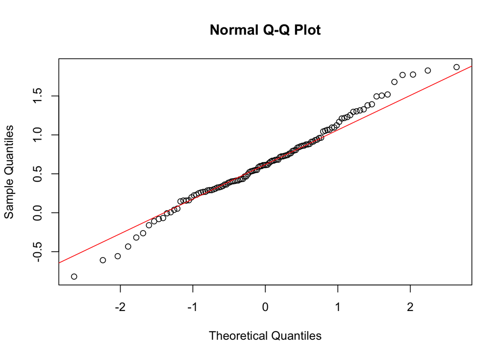

```r
lg_10_score <- log10(d1$score)
qqnorm(lg_10_score)
qqline(lg_10_score, col="red")
```

Now two lines look more similar than the previous one. It is normally distributed.

## 10

```r
t.test(log10(d1_ctl$score), log10(d1_vac$score), paired = TRUE)
```

```
##
##  Paired t-test
##
## data:  log10(d1_ctl$score) and log10(d1_vac$score)
## t = 4.999, df = 59, p-value = 5.468e-06
## alternative hypothesis: true mean difference is not equal to 0
## 95 percent confidence interval:
##  0.2644566 0.6174734
## sample estimates:
## mean difference
##        0.440965
```

The p-value is very small here. We got a very small p-value and thus we have enough evidence to reject the null hypothesis and conclude that these two groups have difference in means of score

## 11

```r
ctl_mean <- mean(d1_ctl$score)
ctl_sd <- sd(d1_ctl$score)
dim(d1_ctl)
```

```
## [1] 60  3
```

```r
ctl_upper <- ctl_mean + ctl_sd/sqrt(60)
ctl_lower <- ctl_mean - ctl_sd/sqrt(60)
print(paste0("The upper bound is ", ctl_upper))
```

```
## [1] "The upper bound is 15.1721294609707"
```

```r
print(paste0("The lower bound is ", ctl_lower))
```

```
## [1] "The lower bound is 10.8513846274067"
```

```r
vac_mean <- mean(d1_vac$score)
vac_sd <- sd(d1_vac$score)
dim(d1_vac)
```

```
## [1] 60  3
```

```r
vac_upper <- vac_mean + vac_sd/sqrt(60)
vac_lower <- vac_mean - vac_sd/sqrt(60)
print(paste0("The upper bound is ", vac_upper))
```

```
## [1] "The upper bound is 4.99130349331046"
```

```r
print(paste0("The lower bound is ", vac_lower))
```

```
## [1] "The lower bound is 3.64991655267385"
```

```r
hpv_mean <- c(ctl_mean, vac_mean)
hpv_lower_ci <- c(ctl_lower, vac_lower)
hpv_upper_ci <- c(ctl_upper, vac_upper)
hpv_index <- c('control', 'vaccinated')
df <- data.frame(hpv_index, hpv_mean, hpv_lower_ci, hpv_upper_ci)
df
```

```
##    hpv_index hpv_mean hpv_lower_ci hpv_upper_ci
## 1    control 13.01176    10.851385    15.172129
## 2 vaccinated  4.32061     3.649917     4.991303
```

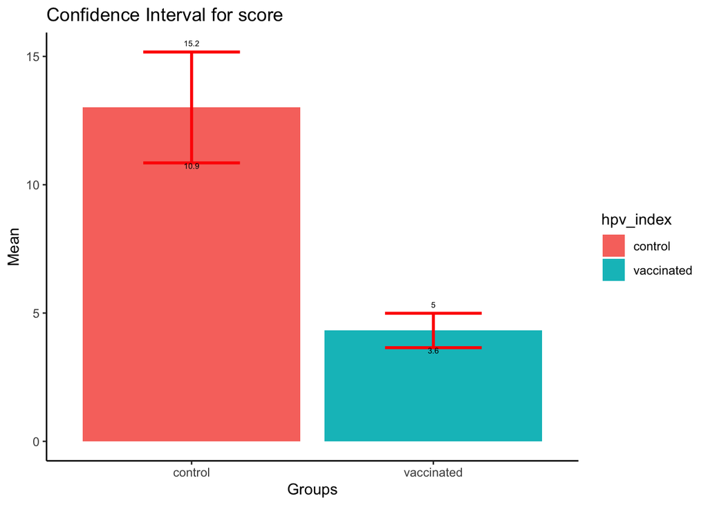

```r
ggplot(data = df) +
  geom_bar(aes(x=hpv_index, y=hpv_mean, fill = hpv_index), stat = "identity") +
  geom_errorbar(aes(x=hpv_index, ymin = hpv_lower_ci, ymax = hpv_upper_ci), width = 0.4, color = "red", size = 1) +
  geom_text(aes(x=hpv_index, y = hpv_lower_ci, label = round(hpv_lower_ci, 1)), size = 2, vjust = 1) +
  geom_text(aes(x=hpv_index, y = hpv_upper_ci, label = round(hpv_upper_ci, 1)), size = 2, vjust = -1) +
  theme_classic() +
  labs(title = "Confidence Interval for score") +
  labs(x="Groups", y = "Mean")
```

## 12

Yes. We can observe the obvious differences between two groups.

## 13

The percentage of the effectiveness of vaccines over that of placebo on average.

## Task2

## 1

```r
 # Download the data
d3 <- read.csv("http://faraway.neu.edu/biostats/lab4_dataset3.csv")
d3
```

```
##    year    autism  vaccine
## 1  1950 0.8747092 5.079621
## 2  1951 1.0775450 4.979636
## 3  1952 0.9145069 5.272306
## 4  1953 1.4415051 5.080250
## 5  1954 1.2291669 5.694768
## 6  1955 1.0399880 5.906284
## 7  1956 1.3423838 5.538801
## 8  1957 1.4333792 5.505459
## 9  1958 1.4416869 5.930270
## 10 1959 1.3062693 5.891356
## 11 1960 1.7105195 6.500732
## 12 1961 1.5269482 6.114601
## 13 1962 1.3655478 6.362438
## 14 1963 1.0876723 6.332131
```

[output cut: 36 more lines]

## 2

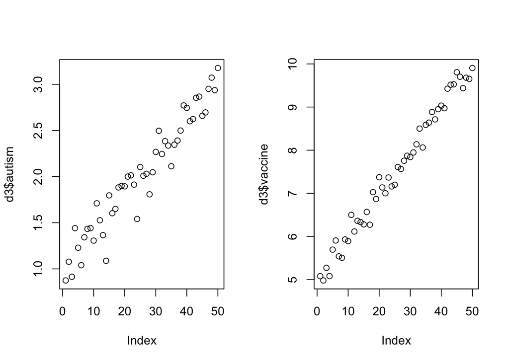

```r
par(mfrow=c(1,2))
plot(d3$autism)
plot(d3$vaccine)
```

We can see the trends in these two variables are the same.

## 3

Considering the humanity, I decide to design an experiment like this: we can first choose a large sample of infants, like 100,000. Then we can record how many of them have the vaccines, and we can choose the same number of children who do not receive vaccines in the same sample randomly, and here we have our final sample. And for the replication purpose, we can choose 1 million infants at first, and divide them into 10 replications. Or we can use smaller sample size(from 100,000 to 10,000)

## 4

```r
# Download the data
d4 <- read.csv("http://faraway.neu.edu/biostats/lab4_dataset4.csv")
d4
```

```
##     treatment     autism
## 1     control  3.5735024
## 2     control  8.0336850
## 3     control  2.8990161
## 4     control 32.9595418
## 5     control  9.2952895
## 6     control  2.9433006
## 7     control 10.8854720
## 8     control 13.9897470
## 9     control 11.8909945
## 10    control  4.9264153
## 11    control 30.3191998
## 12    control  9.8733898
## 13    control  3.5921806
## 14    control  0.7300079
```

[output cut: 106 more lines]

## 5

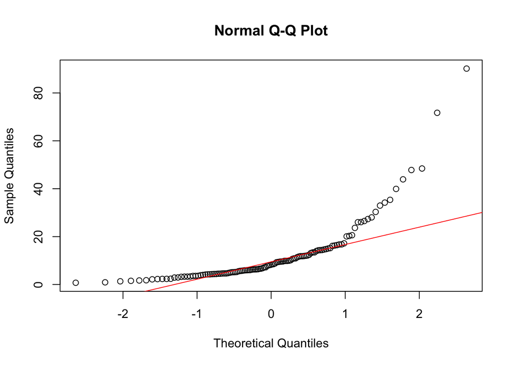

```r
qqnorm(d4$autism)
qqline(d4$autism, col="red")
```

```r
d4_ctl <- subset(d4, treatment == "control")
d4_vac <- subset(d4, treatment == "vaccine")
t.test(log10(d4_ctl$autism), log10(d4_vac$autism), paired = TRUE)
```

```
##
##  Paired t-test
##
## data:  log10(d4_ctl$autism) and log10(d4_vac$autism)
## t = -1.2362, df = 59, p-value = 0.2213
## alternative hypothesis: true mean difference is not equal to 0
## 95 percent confidence interval:
##  -0.2322159  0.0548596
## sample estimates:
## mean difference
##     -0.08867817
```

## 6

```r
ctl_mean <- mean(d4_ctl$autism)
ctl_sd <- sd(d4_ctl$autism)
dim(d4_ctl)
```

```
## [1] 60  2
```

```r
ctl_upper <- ctl_mean + ctl_sd/sqrt(60)
ctl_lower <- ctl_mean - ctl_sd/sqrt(60)
print(paste0("The upper bound is ", ctl_upper))
```

```
## [1] "The upper bound is 11.4404576709074"
```

```r
print(paste0("The lower bound is ", ctl_lower))
```

```
## [1] "The lower bound is 9.17134006953879"
```

```r
vac_mean <- mean(d4_vac$autism)
vac_sd <- sd(d4_vac$autism)
dim(d4_vac)
```

```
## [1] 60  2
```

```r
vac_upper <- vac_mean + vac_sd/sqrt(60)
vac_lower <- vac_mean - vac_sd/sqrt(60)
print(paste0("The upper bound is ", vac_upper))
```

```
## [1] "The upper bound is 16.3746954926797"
```

```r
print(paste0("The lower bound is ", vac_lower))
```

```
## [1] "The lower bound is 12.1072903849752"
```

```r
aut_mean <- c(ctl_mean, vac_mean)
aut_lower_ci <- c(ctl_lower, vac_lower)
aut_upper_ci <- c(ctl_upper, vac_upper)
aut_index <- c('control', 'vaccinated')
df <- data.frame(aut_index, aut_mean, aut_lower_ci, aut_upper_ci)
df
```

```
##    aut_index aut_mean aut_lower_ci aut_upper_ci
## 1    control 10.30590      9.17134     11.44046
## 2 vaccinated 14.24099     12.10729     16.37470
```

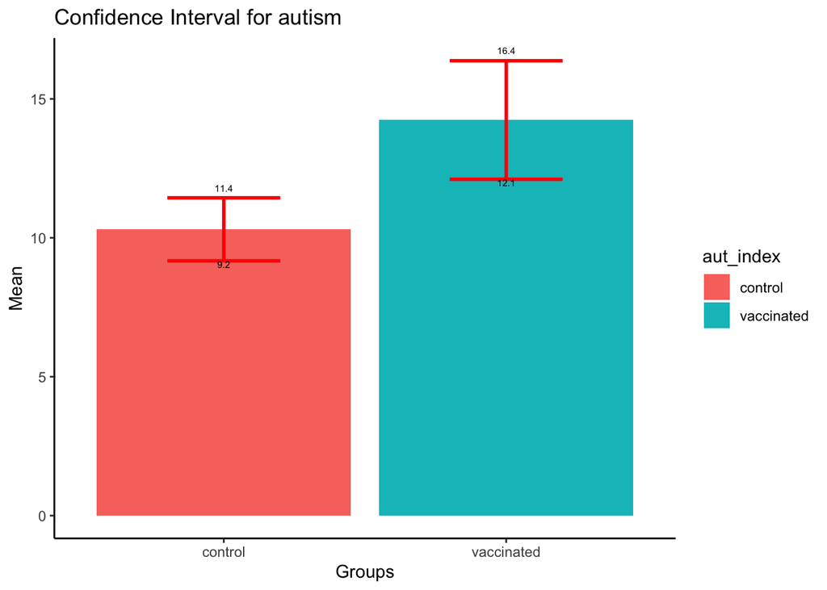

```r
ggplot(data = df) +
  geom_bar(aes(x=aut_index, y=aut_mean, fill = aut_index), stat = "identity") +
  geom_errorbar(aes(x=aut_index, ymin = aut_lower_ci, ymax = aut_upper_ci), width = 0.4, color = "red", size = 1) +
  geom_text(aes(x=aut_index, y = aut_lower_ci, label = round(aut_lower_ci, 1)), size = 2, vjust = 1) +
  geom_text(aes(x=aut_index, y = aut_upper_ci, label = round(aut_upper_ci, 1)), size = 2, vjust = -1) +
  theme_classic() +
  labs(title = "Confidence Interval for autism") +
  labs(x="Groups", y = "Mean")
```

## 7

We observe that the vaccine and autism have dependencies but cannot determine the causality.